# YRBS Analysis with XGBoost

Bin Kim

10/27/2020

```r
library(tidyverse)
library(xgboost)
load("yrbs.rda")
```

# Task 1: Build a classifier to predict labels r from x with xgboost, and show the confusion matrix

## Data Preparation

```r
yrbs = x
yrbs$r = r
yrbs = yrbs %>%
    filter(!is.na(r))
```

## Model Fitting

```r
table(yrbs$r)
```

```
##
##    0    1    2    3    4    5    6    7
##  163  627 1667  100 6849 2365 2756  739
```

There are only 163 observations for group 0 (American Indian/Native) and 100 for group 3 (Hawaiian/Pacific). Doing a train-test split risks ruining the model by including very few observations of these groups. Doing a standard 5-fold.

```r
yrbs_x = apply(as.matrix(yrbs[, -95]), 2, as.numeric)
yrbs_r = apply(as.matrix(yrbs[, 95]), 2, as.numeric)
```

```r
# Standard Settings
set.seed(763)
yrbs_xgb_cv = xgb.cv(data = yrbs_x, label = yrbs_r, nrounds = 300, objective = "multi:softmax", num_class = 8, nfold = 5, early_stopping_rounds = 15, eta = 0.2, lambda = 1, max_depth = 3)
```

[output not shown]

## Fit The Best Model

```r
set.seed(763)
yrbs_fit = xgboost(data = yrbs_x, label = yrbs_r, nrounds = 96, objective = "multi:softmax", num_class = 8, nfold = 5, eta = 0.2, lambda = 1, max_depth = 3)
```

[output not shown]

```r
# Confusion Matrix
conf_mat = table(predict(yrbs_fit, newdata = yrbs_x), yrbs_r)
conf_mat
```

```
##    yrbs_r
##        0    1    2    3    4    5    6    7
##   0   11    0    0    0    0    0    0    0
##   1    4  230   15    3   19   20   34   17
##   2    9   31  972   16  151  138  203   94
##   3    0    0    0   19    0    0    0    0
##   4   92  224  348   33 6236  676 1055  450
##   5   17   89  162   13  219 1178  500   60
##   6   29   52  170   16  223  351  963   92
##   7    1    1    0    0    1    2    1   26
```

```r
# Number of observations per group
group_sum = apply(conf_mat, 2, sum)
group_sum
```

```
##    0    1    2    3    4    5    6    7
##  163  627 1667  100 6849 2365 2756  739
```

```r
# get proportions of correctly classified per group.
correct_class = NULL
for (i in 1:8) {
    correct_class = c(correct_class, conf_mat[i,i])
}

correct_prop = correct_class / group_sum
correct_prop
```

```
##          0          1          2          3          4          5          6
## 0.06748466 0.36682616 0.58308338 0.19000000 0.91049788 0.49809725 0.34941945
##          7
## 0.03518268
```

# Task 2: Describe and visualise which variables are most important in the prediction.

```r
yrtb_importance =xgb.importance(model=yrbs_fit)
yrtb_importance
```

```
##     Feature         Gain        Cover    Frequency
##  1:     q97 1.490644e-01 4.414455e-02 0.0259492463
##  2:      q9 6.682442e-02 1.783389e-02 0.0131654264
##  3:      q8 6.336874e-02 2.108098e-02 0.0143102461
##  4:     q99 4.596516e-02 2.349070e-02 0.0154550658
##  5:      q6 4.427538e-02 5.462227e-02 0.0412135089
##  6:     q89 2.798206e-02 3.103568e-02 0.0284296890
##  7:     q13 2.739291e-02 2.111422e-02 0.0181263118
##  8:      q7 2.514764e-02 3.115128e-02 0.0484640336
##  9:     q70 1.730661e-02 1.698565e-02 0.0118298035
## 10:     q78 1.660342e-02 1.744653e-02 0.0186987216
## 11:     q37 1.656780e-02 2.300320e-02 0.0154550658
## 12:     q71 1.649092e-02 2.558853e-02 0.0186987216
## 13:     q81 1.616685e-02 1.379837e-02 0.0167906888
## 14:     q84 1.610111e-02 1.292882e-02 0.0171722954
```

[output cut: 81 more lines]

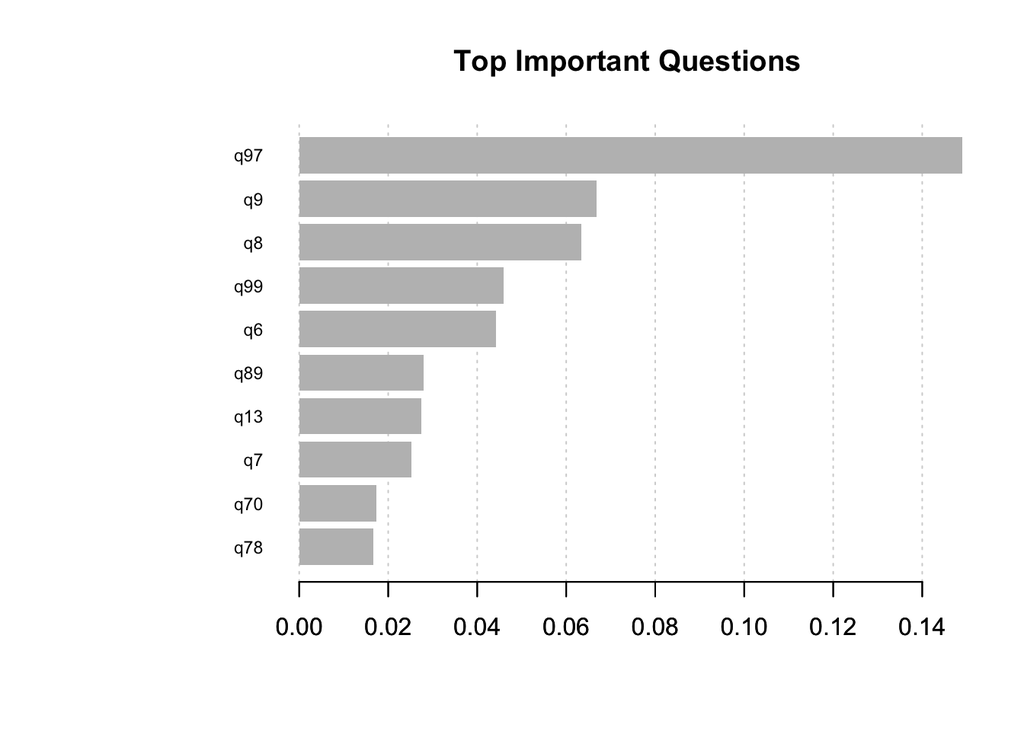

```r
xgb.plot.importance(yrtb_importance, top_n = 10, main = "Top Important Questions")
```

Question 97: "...how many times have you had a sunburn?..." was the most influential question in classifying the race of a student. We will also examine Question 9: "How often do you wear a seat belt when riding in a car driven by someone else?", Question 8: "When you rode a bicycle during the past 12 months, how often did you wear a helmet?", Question 89 "Average grades for the past 12 months", and Question 13 "How many days of the week are you carrying weapons?".

# Task 3: Describe and display the relationships between the most important variables and the label categories – which category/categories is each of the most important variables useful for predicting? Can you produce a summary of the most distinctive predictors for each label category?

[figure not shown]

```r
q97_table = table(yrbs_x[,"q97"], yrbs_r)
for (col in 1:ncol(q97_table)) {
    total = sum(q97_table[,col])
    q97_table[,col] = q97_table[,col] / total
}

as.data.frame(q97_table) %>% mutate(Var1 = recode_factor(Var1, `1` = "0", `2` = "1", `3` = "2", `4` = "3", `5` = "4", `6` = "5 or more")) %>%
    ggplot(aes(fill=factor(Var1, c("5 or more", 4:0)), x=yrbs_r, y=Freq)) + geom_bar(position = "fill", stat="identity") +
    labs(fill="Answer", title = "# Sunburn per Week: Answer Proportion by Race") + xlab("Group") + ylab("%") +
    scale_x_discrete(breaks=0:7, labels=c("Asian", "Black", "Nat-Ind", "Hwi/Pcf", "White", "Lat", "Multi/Lat", "Multi"))
```

White students notably get more sunburns than other groups.

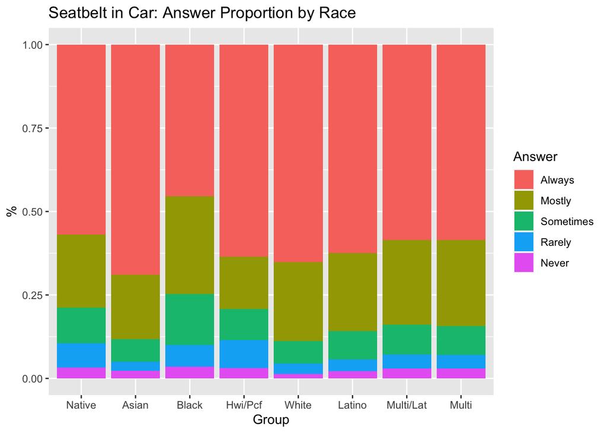

```r
q9_table = table(yrbs_x[,"q9"], yrbs_r)
for (col in 1:ncol(q9_table)) {
    total = sum(q9_table[,col])
    q9_table[,col] = q9_table[,col] / total
}

as.data.frame(q9_table) %>% mutate(Var1 = recode_factor(Var1, `1` = "Never", `2` = "Rarely", `3` = "Sometimes", `4` = "Mostly", `5` = "Always")) %>%
    ggplot(aes(fill=factor(Var1, rev(c("Never", "Rarely", "Sometimes", "Mostly", "Always"))), x=yrbs_r, y=Freq)) +
    geom_bar(position = "fill", stat="identity") +
    labs(fill="Answer", title = "Seatbelt in Car: Answer Proportion by Race") + xlab("Group") + ylab("%") +
    scale_x_discrete(breaks=0:7, labels=c("Native", "Asian", "Black", "Hwi/Pcf", "White", "Latino", "Multi/Lat", "Multi"))
```

Black students have the lowest proportion of students who answered "Always".

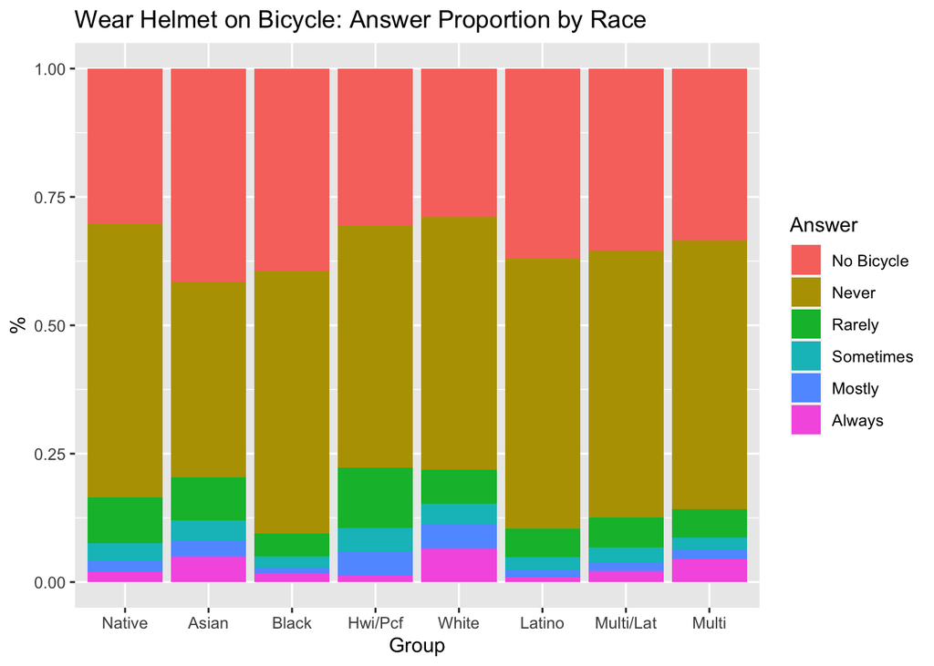

```r
q8_table = table(yrbs_x[,"q8"], yrbs_r)
for (col in 1:ncol(q8_table)) {
    total = sum(q8_table[,col])
    q8_table[,col] = q8_table[,col] / total
}

as.data.frame(q8_table) %>% mutate(Var1 = recode_factor(Var1, `1` = "No Bicycle", `2` = "Never", `3` = "Rarely", `4` = "Sometimes", `5` = "Mostly", `6` = "Always")) %>%
    ggplot(aes(fill=factor(Var1, c("No Bicycle", "Never", "Rarely", "Sometimes", "Mostly", "Always")), x=yrbs_r, y=Freq)) +
    geom_bar(position = "fill", stat="identity") +
    labs(fill="Answer", title = "Wear Helmet on Bicycle: Answer Proportion by Race") + xlab("Group") + ylab("%") +
    scale_x_discrete(breaks=0:7, labels=c("Native", "Asian", "Black", "Hwi/Pcf", "White", "Latino", "Multi/Lat", "Multi"))
```

Hard to distinguish particular differences for this question. Asian students seem to ride less bikes on average. Black and Latino students may be less inclined to wear helmets when riding bicycles.

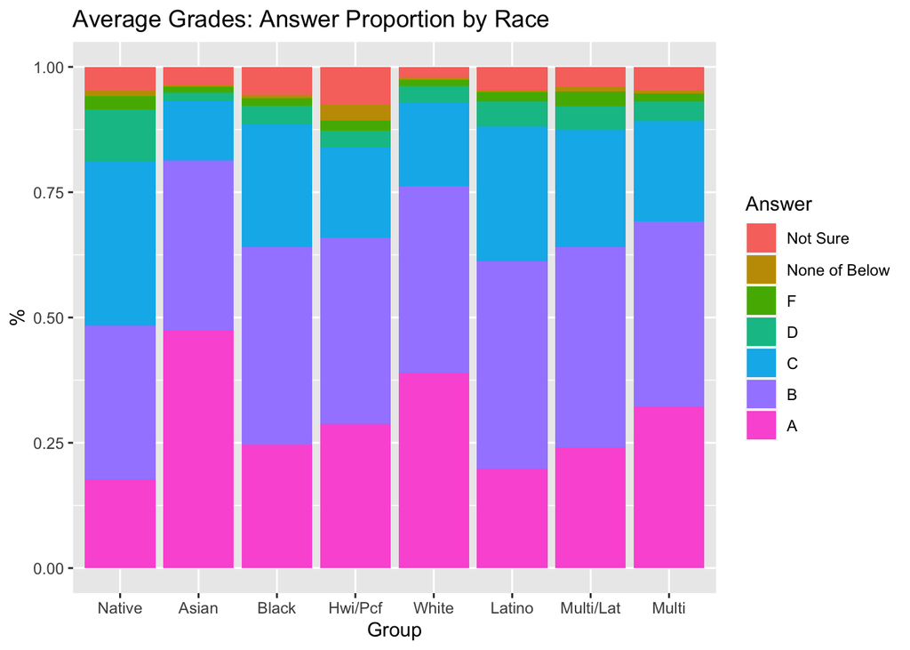

```r
q89_table = table(yrbs_x[,"q89"], yrbs_r)
for (col in 1:ncol(q89_table)) {
    total = sum(q89_table[,col])
    q89_table[,col] = q89_table[,col] / total
}

as.data.frame(q89_table) %>% mutate(Var1 = recode_factor(Var1, `1` = "A", `2` = "B", `3` = "C", `4` = "D", `5` = "F", `6` = "None of Below", `7` = "Not Sure")) %>%
    ggplot(aes(fill=factor(Var1, c("Not Sure", "None of Below", "F", "D", "C", "B", "A")), x=yrbs_r, y=Freq)) +
    geom_bar(position = "fill", stat="identity") +
    labs(fill="Answer", title = "Average Grades: Answer Proportion by Race") + xlab("Group") + ylab("%") +
    scale_x_discrete(breaks=0:7, labels=c("Native", "Asian", "Black", "Hwi/Pcf", "White", "Latino", "Multi/Lat", "Multi"))
```

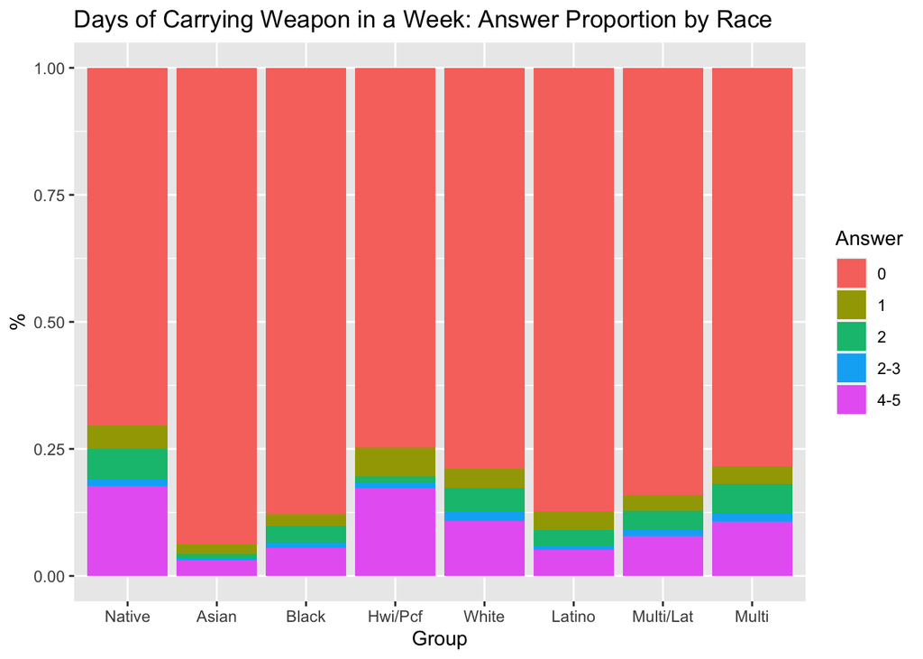

```r
q13_table = table(yrbs_x[,"q13"], yrbs_r)
for (col in 1:ncol(q13_table)) {
    total = sum(q13_table[,col])
    q13_table[,col] = q13_table[,col] / total
}

as.data.frame(q13_table) %>% mutate(Var1 = recode_factor(Var1, `1` = "0", `2` = "1", `3` = "2", `4` = "2-3", `5` = "4-5", `6` = "5 or more")) %>%
    ggplot(aes(fill=factor(Var1), x=yrbs_r, y=Freq)) + geom_bar(position = "fill", stat="identity") +
    labs(fill="Answer", title = "Days of Carrying Weapon in a Week: Answer Proportion by Race") + xlab("Group") + ylab("%") +
    scale_x_discrete(breaks=0:7, labels=c("Native", "Asian", "Black", "Hwi/Pcf", "White", "Latino", "Multi/Lat", "Multi"))
```

Almost no Asian high school students were reported as carrying weapons throughout the week. Natives and the Hawaii/Pacific students seem to have the highest proportion of students carrying weapons.

# Task 4: Comment on whether (or not) task 3 would be ethically problematic if intended to be published, and for what reasons

The YRBS is a data about people's health. The best predictor in the model (Q97) tells us that White students are probably more prone to skin health problems caused by sunburns. Insurance companies may leverage this observation and increase the premiums for the whole White group without properly examining individual differences, and that is discriminatory.

Another factor is that the survey does not take account of students who do not attend high school, or any adults. Any information extracted should be used very carefully if it were to be applied to the whole US adolescent population or general population.